# R Notebook

# Reconhecimento da base

## Vinhos tintos

### Analise exploratoria dos dados

Carregando dados e mostrando as 10 primeiras linhas.

```r
tintos = read.csv("winequality-red.csv", header = TRUE, sep = ";");
head(tintos, 10);
```

|  | fixed.acidity | volatile.acidity | citric.acid | residual.sugar | chlorides | free.sulfur.dioxide | total.sulfur.dioxide | density | pH | sulphates | alcohol | quality |
| --- | --- | --- | --- | --- | --- | --- | --- | --- | --- | --- | --- | --- |
| 1 | 7.4 | 0.70 | 0.00 | 1.9 | 0.076 | 11 | 34 | 0.9978 | 3.51 | 0.56 | 9.4 | 5 |
| 2 | 7.8 | 0.88 | 0.00 | 2.6 | 0.098 | 25 | 67 | 0.9968 | 3.20 | 0.68 | 9.8 | 5 |
| 3 | 7.8 | 0.76 | 0.04 | 2.3 | 0.092 | 15 | 54 | 0.9970 | 3.26 | 0.65 | 9.8 | 5 |
| 4 | 11.2 | 0.28 | 0.56 | 1.9 | 0.075 | 17 | 60 | 0.9980 | 3.16 | 0.58 | 9.8 | 6 |
| 5 | 7.4 | 0.70 | 0.00 | 1.9 | 0.076 | 11 | 34 | 0.9978 | 3.51 | 0.56 | 9.4 | 5 |
| 6 | 7.4 | 0.66 | 0.00 | 1.8 | 0.075 | 13 | 40 | 0.9978 | 3.51 | 0.56 | 9.4 | 5 |
| 7 | 7.9 | 0.60 | 0.06 | 1.6 | 0.069 | 15 | 59 | 0.9964 | 3.30 | 0.46 | 9.4 | 5 |
| 8 | 7.3 | 0.65 | 0.00 | 1.2 | 0.065 | 15 | 21 | 0.9946 | 3.39 | 0.47 | 10.0 | 7 |
| 9 | 7.8 | 0.58 | 0.02 | 2.0 | 0.073 | 9 | 18 | 0.9968 | 3.36 | 0.57 | 9.5 | 7 |
| 10 | 7.5 | 0.50 | 0.36 | 6.1 | 0.071 | 17 | 102 | 0.9978 | 3.35 | 0.80 | 10.5 | 5 |

Colunas

```r
colnames(tintos)
```

```
 [1] "fixed.acidity"        "volatile.acidity"     "citric.acid"          "residual.sugar"
 [5] "chlorides"            "free.sulfur.dioxide"  "total.sulfur.dioxide" "density"
 [9] "pH"                   "sulphates"            "alcohol"              "quality"
```

Valores NA

```r
colSums(is.na(tintos))
```

```
       fixed.acidity     volatile.acidity          citric.acid       residual.sugar            chlorides
                   0                    0                    0                    0                    0
 free.sulfur.dioxide total.sulfur.dioxide              density                   pH            sulphates
                   0                    0                    0                    0                    0
             alcohol              quality
                   0                    0
```

Tipos

```r
sapply(tintos, typeof);
```

```
       fixed.acidity     volatile.acidity          citric.acid       residual.sugar            chlorides
            "double"             "double"             "double"             "double"             "double"
 free.sulfur.dioxide total.sulfur.dioxide              density                   pH            sulphates
            "double"             "double"             "double"             "double"             "double"
             alcohol              quality
            "double"            "integer"
```

Resumo de caracteristicas

```r
summary(tintos);
```

```
 fixed.acidity   volatile.acidity  citric.acid    residual.sugar     chlorides       free.sulfur.dioxide
 Min.   : 4.60   Min.   :0.1200   Min.   :0.000   Min.   : 0.900   Min.   :0.01200   Min.   : 1.00
 1st Qu.: 7.10   1st Qu.:0.3900   1st Qu.:0.090   1st Qu.: 1.900   1st Qu.:0.07000   1st Qu.: 7.00
 Median : 7.90   Median :0.5200   Median :0.260   Median : 2.200   Median :0.07900   Median :14.00
 Mean   : 8.32   Mean   :0.5278   Mean   :0.271   Mean   : 2.539   Mean   :0.08747   Mean   :15.87
 3rd Qu.: 9.20   3rd Qu.:0.6400   3rd Qu.:0.420   3rd Qu.: 2.600   3rd Qu.:0.09000   3rd Qu.:21.00
 Max.   :15.90   Max.   :1.5800   Max.   :1.000   Max.   :15.500   Max.   :0.61100   Max.   :72.00
 total.sulfur.dioxide    density             pH          sulphates         alcohol         quality
 Min.   :  6.00       Min.   :0.9901   Min.   :2.740   Min.   :0.3300   Min.   : 8.40   Min.   :3.000
 1st Qu.: 22.00       1st Qu.:0.9956   1st Qu.:3.210   1st Qu.:0.5500   1st Qu.: 9.50   1st Qu.:5.000
 Median : 38.00       Median :0.9968   Median :3.310   Median :0.6200   Median :10.20   Median :6.000
 Mean   : 46.47       Mean   :0.9967   Mean   :3.311   Mean   :0.6581   Mean   :10.42   Mean   :5.636
 3rd Qu.: 62.00       3rd Qu.:0.9978   3rd Qu.:3.400   3rd Qu.:0.7300   3rd Qu.:11.10   3rd Qu.:6.000
 Max.   :289.00       Max.   :1.0037   Max.   :4.010   Max.   :2.0000   Max.   :14.90   Max.   :8.000
```

Deteccao de outliers

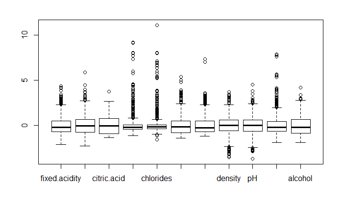

```r
boxplot(scale(tintos[, -12]))
```

## Vinhos brancos

### Analise exploratoria dos dados

Carregando dados e mostrando as 10 primeiras linhas.

```r
brancos = read.csv("winequality-white.csv", header = TRUE, sep = ";");
head(brancos, 10);
```

|  | fixed.acidity | volatile.acidity | citric.acid | residual.sugar | chlorides | free.sulfur.dioxide | total.sulfur.dioxide | density | pH | sulphates | alcohol | quality |
| --- | --- | --- | --- | --- | --- | --- | --- | --- | --- | --- | --- | --- |
| 1 | 7.0 | 0.27 | 0.36 | 20.7 | 0.045 | 45 | 170 | 1.0010 | 3.00 | 0.45 | 8.8 | 6 |
| 2 | 6.3 | 0.30 | 0.34 | 1.6 | 0.049 | 14 | 132 | 0.9940 | 3.30 | 0.49 | 9.5 | 6 |
| 3 | 8.1 | 0.28 | 0.40 | 6.9 | 0.050 | 30 | 97 | 0.9951 | 3.26 | 0.44 | 10.1 | 6 |
| 4 | 7.2 | 0.23 | 0.32 | 8.5 | 0.058 | 47 | 186 | 0.9956 | 3.19 | 0.40 | 9.9 | 6 |
| 5 | 7.2 | 0.23 | 0.32 | 8.5 | 0.058 | 47 | 186 | 0.9956 | 3.19 | 0.40 | 9.9 | 6 |
| 6 | 8.1 | 0.28 | 0.40 | 6.9 | 0.050 | 30 | 97 | 0.9951 | 3.26 | 0.44 | 10.1 | 6 |
| 7 | 6.2 | 0.32 | 0.16 | 7.0 | 0.045 | 30 | 136 | 0.9949 | 3.18 | 0.47 | 9.6 | 6 |
| 8 | 7.0 | 0.27 | 0.36 | 20.7 | 0.045 | 45 | 170 | 1.0010 | 3.00 | 0.45 | 8.8 | 6 |
| 9 | 6.3 | 0.30 | 0.34 | 1.6 | 0.049 | 14 | 132 | 0.9940 | 3.30 | 0.49 | 9.5 | 6 |
| 10 | 8.1 | 0.22 | 0.43 | 1.5 | 0.044 | 28 | 129 | 0.9938 | 3.22 | 0.45 | 11.0 | 6 |

Colunas

```r
colnames(brancos)
```

```
 [1] "fixed.acidity"        "volatile.acidity"     "citric.acid"          "residual.sugar"
 [5] "chlorides"            "free.sulfur.dioxide"  "total.sulfur.dioxide" "density"
 [9] "pH"                   "sulphates"            "alcohol"              "quality"
```

Valores NA

```r
colSums(is.na(brancos))
```

```
       fixed.acidity     volatile.acidity          citric.acid       residual.sugar            chlorides
                   0                    0                    0                    0                    0
 free.sulfur.dioxide total.sulfur.dioxide              density                   pH            sulphates
                   0                    0                    0                    0                    0
             alcohol              quality
                   0                    0
```

Tipos

```r
sapply(brancos, typeof);
```

```
       fixed.acidity     volatile.acidity          citric.acid       residual.sugar            chlorides
            "double"             "double"             "double"             "double"             "double"
 free.sulfur.dioxide total.sulfur.dioxide              density                   pH            sulphates
            "double"             "double"             "double"             "double"             "double"
             alcohol              quality
            "double"            "integer"
```

Resumo de caracteristicas

```r
summary(brancos);
```

```
 fixed.acidity    volatile.acidity  citric.acid     residual.sugar     chlorides       free.sulfur.dioxide
 Min.   : 3.800   Min.   :0.0800   Min.   :0.0000   Min.   : 0.600   Min.   :0.00900   Min.   :  2.00
 1st Qu.: 6.300   1st Qu.:0.2100   1st Qu.:0.2700   1st Qu.: 1.700   1st Qu.:0.03600   1st Qu.: 23.00
 Median : 6.800   Median :0.2600   Median :0.3200   Median : 5.200   Median :0.04300   Median : 34.00
 Mean   : 6.855   Mean   :0.2782   Mean   :0.3342   Mean   : 6.391   Mean   :0.04577   Mean   : 35.31
 3rd Qu.: 7.300   3rd Qu.:0.3200   3rd Qu.:0.3900   3rd Qu.: 9.900   3rd Qu.:0.05000   3rd Qu.: 46.00
 Max.   :14.200   Max.   :1.1000   Max.   :1.6600   Max.   :65.800   Max.   :0.34600   Max.   :289.00
 total.sulfur.dioxide    density             pH          sulphates         alcohol         quality
 Min.   :  9.0        Min.   :0.9871   Min.   :2.720   Min.   :0.2200   Min.   : 8.00   Min.   :3.000
 1st Qu.:108.0        1st Qu.:0.9917   1st Qu.:3.090   1st Qu.:0.4100   1st Qu.: 9.50   1st Qu.:5.000
 Median :134.0        Median :0.9937   Median :3.180   Median :0.4700   Median :10.40   Median :6.000
 Mean   :138.4        Mean   :0.9940   Mean   :3.188   Mean   :0.4898   Mean   :10.51   Mean   :5.878
 3rd Qu.:167.0        3rd Qu.:0.9961   3rd Qu.:3.280   3rd Qu.:0.5500   3rd Qu.:11.40   3rd Qu.:6.000
 Max.   :440.0        Max.   :1.0390   Max.   :3.820   Max.   :1.0800   Max.   :14.20   Max.   :9.000
```

Deteccao de outliers

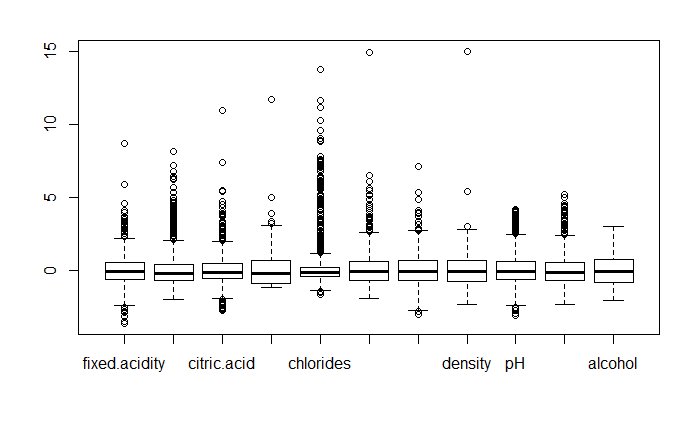

```r
boxplot(scale(brancos[, -12]))
```

## Vinho branco

### Grafico de correlacao

```r
library(corrgram)
cor(brancos)
```

```
                     fixed.acidity volatile.acidity  citric.acid residual.sugar   chlorides free.sulfur.dioxide
fixed.acidity           1.00000000      -0.02269729  0.289180698     0.08902070  0.02308564       -0.0493958591
volatile.acidity       -0.02269729       1.00000000 -0.149471811     0.06428606  0.07051157       -0.0970119393
citric.acid             0.28918070      -0.14947181  1.000000000     0.09421162  0.11436445        0.0940772210
residual.sugar          0.08902070       0.06428606  0.094211624     1.00000000  0.08868454        0.2990983537
chlorides               0.02308564       0.07051157  0.114364448     0.08868454  1.00000000        0.1013923521
free.sulfur.dioxide    -0.04939586      -0.09701194  0.094077221     0.29909835  0.10139235        1.0000000000
total.sulfur.dioxide    0.09106976       0.08926050  0.121130798     0.40143931  0.19891030        0.6155009650
density                 0.26533101       0.02711385  0.149502571     0.83896645  0.25721132        0.2942104109
pH                     -0.42585829      -0.03191537 -0.163748211    -0.19413345 -0.09043946       -0.0006177961
sulphates              -0.01714299      -0.03572815  0.062330940    -0.02666437  0.01676288        0.0592172458
alcohol                -0.12088112       0.06771794 -0.075728730    -0.45063122 -0.36018871       -0.2501039415
quality                -0.11366283      -0.19472297 -0.009209091    -0.09757683 -0.20993441        0.0081580671
                     total.sulfur.dioxide     density            pH   sulphates     alcohol      quality
fixed.acidity                 0.091069756  0.26533101 -0.4258582910 -0.01714299 -0.12088112 -0.113662831
volatile.acidity              0.089260504  0.02711385 -0.0319153683 -0.03572815  0.06771794 -0.194722969
citric.acid                   0.121130798  0.14950257 -0.1637482114  0.06233094 -0.07572873 -0.009209091
residual.sugar                0.401439311  0.83896645 -0.1941334540 -0.02666437 -0.45063122 -0.097576829
chlorides                     0.198910300  0.25721132 -0.0904394560  0.01676288 -0.36018871 -0.209934411
free.sulfur.dioxide           0.615500965  0.29421041 -0.0006177961  0.05921725 -0.25010394  0.008158067
total.sulfur.dioxide          1.000000000  0.52988132  0.0023209718  0.13456237 -0.44889210 -0.174737218
density                       0.529881324  1.00000000 -0.0935914935  0.07449315 -0.78013762 -0.307123313
pH                            0.002320972 -0.09359149  1.0000000000  0.15595150  0.12143210  0.099427246
sulphates                     0.134562367  0.07449315  0.1559514973  1.00000000 -0.01743277  0.053677877
alcohol                      -0.448892102 -0.78013762  0.1214320987 -0.01743277  1.00000000  0.435574715
quality                      -0.174737218 -0.30712331  0.0994272457  0.05367788  0.43557472  1.000000000
```

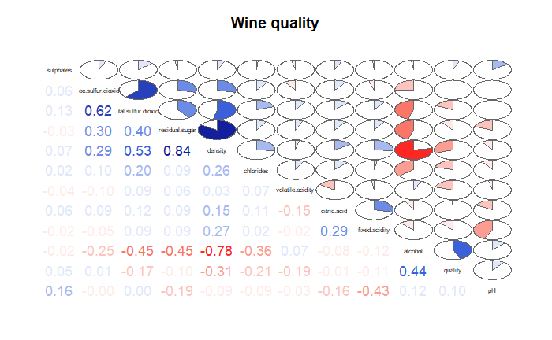

```r
corrgram(brancos, order=TRUE, lower.panel=panel.cor,
  upper.panel=panel.pie, text.panel=panel.txt,
  main="Wine quality")
```

### Boxplot

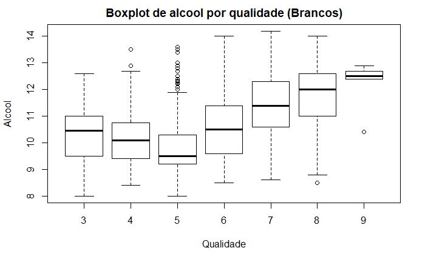

```r
boxplot(alcohol~quality, data=brancos, main='Boxplot de alcool por qualidade (Brancos)', xlab='Qualidade', ylab='Alcool')
```

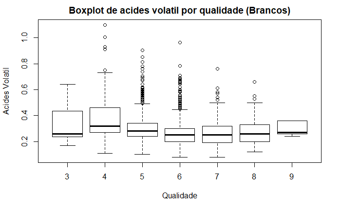

```r
boxplot(volatile.acidity~quality, data=brancos, main='Boxplot de acides volatil por qualidade (Brancos)', xlab='Qualidade', ylab='Acides Volatil')
```

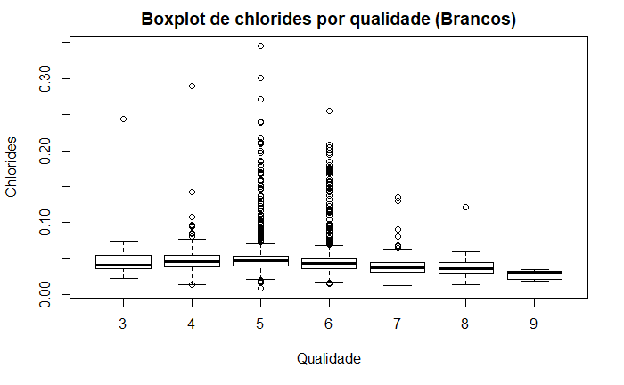

```r
boxplot(chlorides~quality, data=brancos, main='Boxplot de chlorides por qualidade (Brancos)', xlab='Qualidade', ylab='Chlorides')
```

## Vinho tinto

### Grafico de correlacao

```r
cor(tintos)
```

```
                     fixed.acidity volatile.acidity citric.acid residual.sugar    chlorides free.sulfur.dioxide
fixed.acidity           1.00000000     -0.256130895  0.67170343    0.114776724  0.093705186        -0.153794193
volatile.acidity       -0.25613089      1.000000000 -0.55249568    0.001917882  0.061297772        -0.010503827
citric.acid             0.67170343     -0.552495685  1.00000000    0.143577162  0.203822914        -0.060978129
residual.sugar          0.11477672      0.001917882  0.14357716    1.000000000  0.055609535         0.187048995
chlorides               0.09370519      0.061297772  0.20382291    0.055609535  1.000000000         0.005562147
free.sulfur.dioxide    -0.15379419     -0.010503827 -0.06097813    0.187048995  0.005562147         1.000000000
total.sulfur.dioxide   -0.11318144      0.076470005  0.03553302    0.203027882  0.047400468         0.667666450
density                 0.66804729      0.022026232  0.36494718    0.355283371  0.200632327        -0.021945831
pH                     -0.68297819      0.234937294 -0.54190414   -0.085652422 -0.265026131         0.070377499
sulphates               0.18300566     -0.260986685  0.31277004    0.005527121  0.371260481         0.051657572
alcohol                -0.06166827     -0.202288027  0.10990325    0.042075437 -0.221140545        -0.069408354
quality                 0.12405165     -0.390557780  0.22637251    0.013731637 -0.128906560        -0.050656057
                     total.sulfur.dioxide     density          pH    sulphates     alcohol     quality
fixed.acidity                 -0.11318144  0.66804729 -0.68297819  0.183005664 -0.06166827  0.12405165
volatile.acidity               0.07647000  0.02202623  0.23493729 -0.260986685 -0.20228803 -0.39055778
citric.acid                    0.03553302  0.36494718 -0.54190414  0.312770044  0.10990325  0.22637251
residual.sugar                 0.20302788  0.35528337 -0.08565242  0.005527121  0.04207544  0.01373164
chlorides                      0.04740047  0.20063233 -0.26502613  0.371260481 -0.22114054 -0.12890656
free.sulfur.dioxide            0.66766645 -0.02194583  0.07037750  0.051657572 -0.06940835 -0.05065606
total.sulfur.dioxide           1.00000000  0.07126948 -0.06649456  0.042946836 -0.20565394 -0.18510029
density                        0.07126948  1.00000000 -0.34169933  0.148506412 -0.49617977 -0.17491923
pH                            -0.06649456 -0.34169933  1.00000000 -0.196647602  0.20563251 -0.05773139
sulphates                      0.04294684  0.14850641 -0.19664760  1.000000000  0.09359475  0.25139708
alcohol                       -0.20565394 -0.49617977  0.20563251  0.093594750  1.00000000  0.47616632
quality                       -0.18510029 -0.17491923 -0.05773139  0.251397079  0.47616632  1.00000000
```

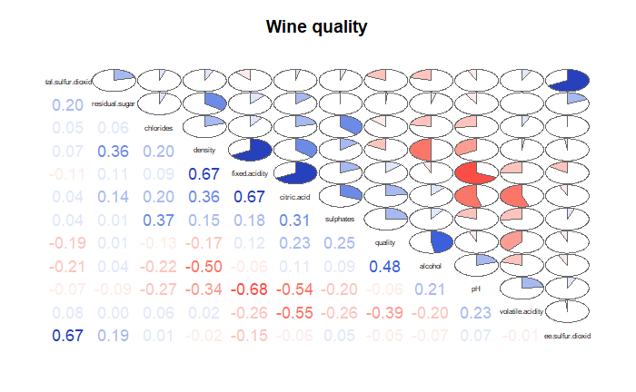

```r
corrgram(tintos, order=TRUE, lower.panel=panel.cor,
  upper.panel=panel.pie, text.panel=panel.txt,
  main="Wine quality")
```

### Boxplot

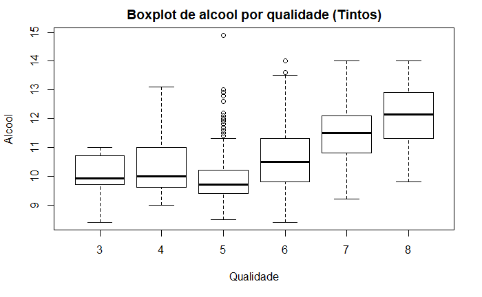

```r
boxplot(alcohol~quality, data=tintos, main='Boxplot de alcool por qualidade (Tintos)', xlab='Qualidade', ylab='Alcool')
```

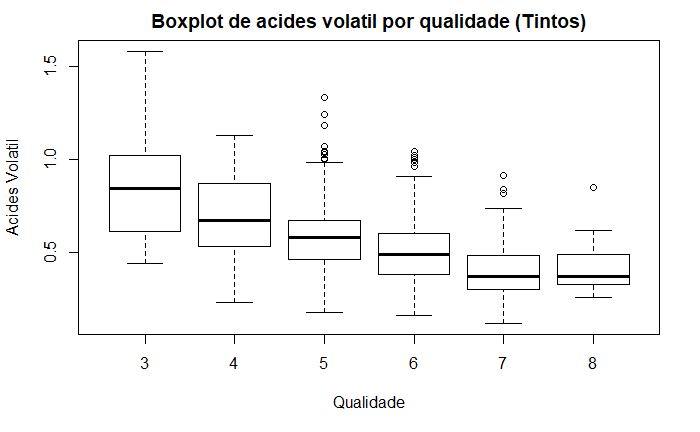

```r
boxplot(volatile.acidity~quality, data=tintos, main='Boxplot de acides volatil por qualidade (Tintos)', xlab='Qualidade', ylab='Acides Volatil')
```

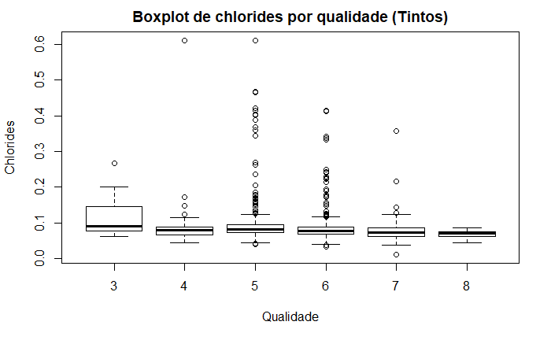

```r
boxplot(chlorides~quality, data=tintos, main='Boxplot de chlorides por qualidade (Tintos)', xlab='Qualidade', ylab='Chlorides')
```

## Decisao: Vinho branco ou tinto?

Resposta: As relacoes entre as variaveis e a qualidade dos vinhos apresentam uma grande distincao entre vinhos tintos e brancos. Por esse motivo, modelos simplificados como, regressoes lineares e regressoes logisticas teriam dificuldade com a uniao das bases. Ja modelos como arvore de decisao e rendom forest conseguem lidar facilmente com categorias distintas em um mesmo modelo.

## Remocao de outliers

Resposta: A analise de deteccao de outliers apresentou uma quantidade muito grande de outliers na base, porem, se existem tantos outliers, provavelmente nao sao. Nossa abordagem sera manter todos os dados na base.

## Variavel dependente

Resposta: Quality

## Variaveis independentes

Resposta: fixed.acidity + volatile.acidity + citric.acid + residual.sugar +  
chlorides + free.sulfur.dioxide + total.sulfur.dioxide + density + pH + sulphates + alcohol

# Geracao de modelos

## Separacao dos dados em treino e teste

```r
tintos$quality_bin = as.integer(tintos$quality > 6)
brancos$quality_bin = as.integer(brancos$quality > 6)
sample_tintos <- sample.int(n = nrow(tintos), size = floor(.75*nrow(tintos)), replace = F)
tintos_train <- tintos[sample_tintos, ]
tintos_test  <- tintos[-sample_tintos, ]
sample_brancos <- sample.int(n = nrow(brancos), size = floor(.75*nrow(brancos)), replace = F)
brancos_train <- brancos[sample_brancos, ]
brancos_test  <- brancos[-sample_brancos, ]
```

## Regressao linear

```r
linear_model_tintos = lm(quality ~ fixed.acidity + volatile.acidity + citric.acid + residual.sugar +
                chlorides + free.sulfur.dioxide + total.sulfur.dioxide + density + pH +
                sulphates + alcohol, data=tintos_train)
summary(linear_model_tintos)
```

```
Call:
lm(formula = quality ~ fixed.acidity + volatile.acidity + citric.acid +
    residual.sugar + chlorides + free.sulfur.dioxide + total.sulfur.dioxide +
    density + pH + sulphates + alcohol, data = tintos_train)

Residuals:
     Min       1Q   Median       3Q      Max
-2.65090 -0.36227 -0.04884  0.46058  1.96926

Coefficients:
                       Estimate Std. Error t value Pr(>|t|)
(Intercept)           2.666e+01  2.428e+01   1.098 0.272443
fixed.acidity         2.175e-02  3.026e-02   0.719 0.472477
volatile.acidity     -1.068e+00  1.390e-01  -7.685 3.19e-14 ***
citric.acid          -1.942e-01  1.691e-01  -1.149 0.250938
residual.sugar        3.042e-02  1.663e-02   1.829 0.067657 .
chlorides            -1.833e+00  4.756e-01  -3.854 0.000123 ***
free.sulfur.dioxide   4.568e-03  2.496e-03   1.830 0.067484 .
total.sulfur.dioxide -3.708e-03  8.258e-04  -4.491 7.78e-06 ***
density              -2.234e+01  2.480e+01  -0.901 0.367918
pH                   -4.505e-01  2.195e-01  -2.053 0.040318 *
sulphates             9.233e-01  1.279e-01   7.221 9.19e-13 ***
alcohol               2.610e-01  3.022e-02   8.636  < 2e-16 ***
---
Signif. codes:  0 *** 0.001 ** 0.01 * 0.05 . 0.1   1

Residual standard error: 0.6509 on 1187 degrees of freedom
Multiple R-squared:  0.3515,    Adjusted R-squared:  0.3455
F-statistic: 58.49 on 11 and 1187 DF,  p-value: < 2.2e-16
```

```r
linear_model_brancos = lm(quality ~ fixed.acidity + volatile.acidity + citric.acid + residual.sugar +
                chlorides + free.sulfur.dioxide + total.sulfur.dioxide + density + pH +
                sulphates + alcohol, data=brancos_train)
summary(linear_model_brancos)
```

```
Call:
lm(formula = quality ~ fixed.acidity + volatile.acidity + citric.acid +
    residual.sugar + chlorides + free.sulfur.dioxide + total.sulfur.dioxide +
    density + pH + sulphates + alcohol, data = brancos_train)

Residuals:
    Min      1Q  Median      3Q     Max
-3.6434 -0.5029 -0.0485  0.4663  3.1145

Coefficients:
                       Estimate Std. Error t value Pr(>|t|)
(Intercept)           2.074e+02  2.614e+01   7.936 2.74e-15 ***
fixed.acidity         1.158e-01  2.620e-02   4.420 1.02e-05 ***
volatile.acidity     -1.783e+00  1.289e-01 -13.827  < 2e-16 ***
citric.acid          -1.957e-02  1.080e-01  -0.181 0.856185
residual.sugar        9.608e-02  9.858e-03   9.746  < 2e-16 ***
chlorides            -6.827e-01  6.205e-01  -1.100 0.271296
free.sulfur.dioxide   4.745e-03  9.886e-04   4.800 1.65e-06 ***
total.sulfur.dioxide  1.538e-04  4.464e-04   0.344 0.730529
density              -2.080e+02  2.648e+01  -7.856 5.19e-15 ***
pH                    8.216e-01  1.287e-01   6.385 1.93e-10 ***
sulphates             7.049e-01  1.160e-01   6.075 1.37e-09 ***
alcohol               1.159e-01  3.335e-02   3.475 0.000516 ***
---
Signif. codes:  0 *** 0.001 ** 0.01 * 0.05 . 0.1   1

Residual standard error: 0.7468 on 3661 degrees of freedom
Multiple R-squared:  0.285, Adjusted R-squared:  0.2828
F-statistic: 132.7 on 11 and 3661 DF,  p-value: < 2.2e-16
```

### Sobre a tecnica

Essa tecnica cria uma funcao linear multivariada para prever os novos casos: y = a + bx1 + bx2 … + bxn

### Qualidade do modelo

#### Percentual de acerto da regress?o linear na base de teste dos vinhos tintos

```r
prediction_lm_tintos = predict(linear_model_tintos, tintos_test)
accuracy_lm_tintos = 1 - (sum(abs(tintos_test$quality - prediction_lm_tintos)) / sum(tintos_test$quality))
print(accuracy_lm_tintos)
```

```
[1] 0.9138987
```

#### Percentual de acerto da regress?o linear na base de teste dos vinhos brancos

```r
prediction_lm_brancos = predict(linear_model_brancos, brancos_test)
accuracy_lm_brancos = 1 - (sum(abs(brancos_test$quality - prediction_lm_brancos)) / sum(brancos_test$quality))
print(accuracy_lm_brancos)
```

```
[1] 0.8994769
```

## Arvore de regressao

### Tintos

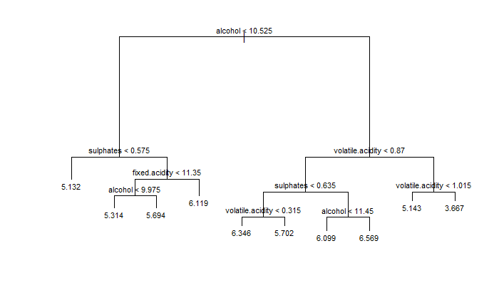

```r
library(tree)
regression_tree_tintos = tree(quality ~ fixed.acidity + volatile.acidity + citric.acid + residual.sugar +
                chlorides + free.sulfur.dioxide + total.sulfur.dioxide + density + pH +
                sulphates + alcohol, data=tintos_train)
plot(regression_tree_tintos)
text(regression_tree_tintos, cex=0.7)
```

```r
summary(regression_tree_tintos)
```

```
Regression tree:
tree(formula = quality ~ fixed.acidity + volatile.acidity + citric.acid +
    residual.sugar + chlorides + free.sulfur.dioxide + total.sulfur.dioxide +
    density + pH + sulphates + alcohol, data = tintos_train)
Variables actually used in tree construction:
[1] "alcohol"          "sulphates"        "fixed.acidity"    "volatile.acidity"
Number of terminal nodes:  10
Residual mean deviance:  0.4136 = 491.8 / 1189
Distribution of residuals:
   Min. 1st Qu.  Median    Mean 3rd Qu.    Max.
-2.3140 -0.3143 -0.1319  0.0000  0.4310  2.3060
```

### Brancos

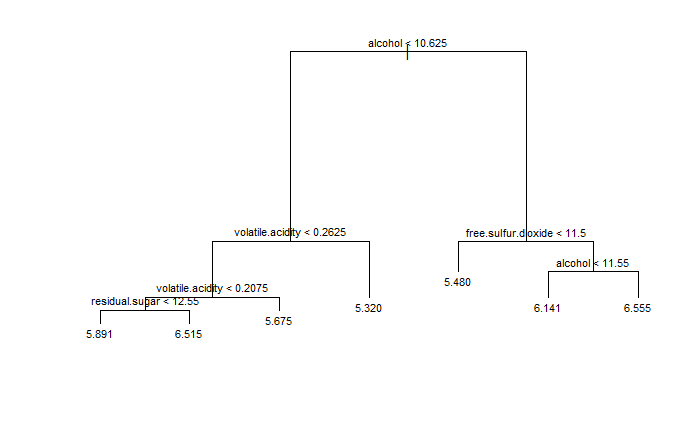

```r
regression_tree_brancos = tree(quality ~ fixed.acidity + volatile.acidity + citric.acid + residual.sugar +
                chlorides + free.sulfur.dioxide + total.sulfur.dioxide + density + pH +
                sulphates + alcohol, data=brancos_train)
plot(regression_tree_brancos)
text(regression_tree_brancos, cex=0.7)
```

```r
summary(regression_tree_brancos)
```

```
Regression tree:
tree(formula = quality ~ fixed.acidity + volatile.acidity + citric.acid +
    residual.sugar + chlorides + free.sulfur.dioxide + total.sulfur.dioxide +
    density + pH + sulphates + alcohol, data = brancos_train)
Variables actually used in tree construction:
[1] "alcohol"             "volatile.acidity"    "residual.sugar"      "free.sulfur.dioxide"
Number of terminal nodes:  7
Residual mean deviance:  0.5642 = 2068 / 3666
Distribution of residuals:
   Min. 1st Qu.  Median    Mean 3rd Qu.    Max.
-3.5550 -0.5554 -0.1406  0.0000  0.4446  3.6800
```

### Sobre a tecnica

Esse modelo controi uma hierarquia de condicionais para prever uma variavel continua

### Qualidade do modelo

#### Percentual de acerto da arvore de regressao na base de teste dos vinhos tintos

```r
prediction_rt_tintos = predict(regression_tree_tintos, tintos_test)
accuracy_rt_tintos = 1 - (sum(abs(tintos_test$quality - prediction_rt_tintos)) / sum(tintos_test$quality))
print(accuracy_rt_tintos)
```

```
[1] 0.9096046
```

#### Percentual de acerto da arvore de regressao na base de teste dos vinhos brancos

```r
prediction_rt_brancos = predict(regression_tree_brancos, brancos_test)
accuracy_rt_brancos = 1 - (sum(abs(brancos_test$quality - prediction_rt_brancos)) / sum(brancos_test$quality))
print(accuracy_rt_brancos)
```

```
[1] 0.8975929
```

## Arvore de decisao

### Tintos

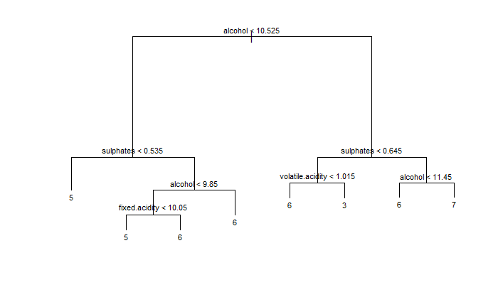

```r
library(tree)
tintos_train$quality_factor = factor(tintos_train$quality)
decision_tree_tintos = tree(quality_factor ~ fixed.acidity + volatile.acidity + citric.acid + residual.sugar +
                chlorides + free.sulfur.dioxide + total.sulfur.dioxide + density + pH +
                sulphates + alcohol, data=tintos_train)
plot(decision_tree_tintos)
text(decision_tree_tintos, cex=0.7)
```

```r
summary(decision_tree_tintos)
```

```
Classification tree:
tree(formula = quality_factor ~ fixed.acidity + volatile.acidity +
    citric.acid + residual.sugar + chlorides + free.sulfur.dioxide +
    total.sulfur.dioxide + density + pH + sulphates + alcohol,
    data = tintos_train)
Variables actually used in tree construction:
[1] "alcohol"          "sulphates"        "fixed.acidity"    "volatile.acidity"
Number of terminal nodes:  8
Residual mean deviance:  1.901 = 2264 / 1191
Misclassification error rate: 0.4053 = 486 / 1199
```

### Brancos

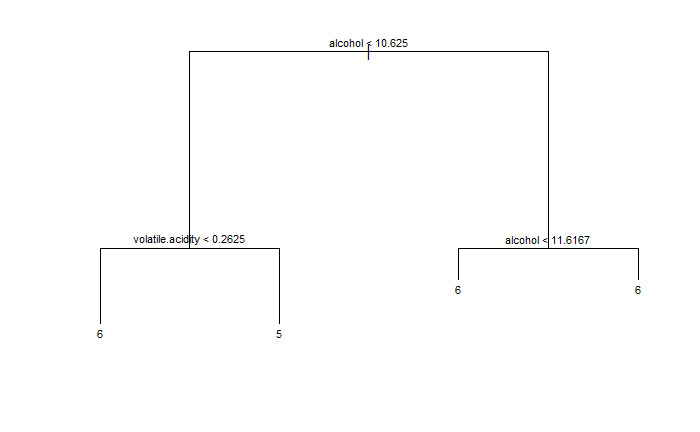

```r
library(tree)
brancos_train$quality_factor = factor(brancos_train$quality)
decision_tree_brancos = tree(quality_factor ~ fixed.acidity + volatile.acidity + citric.acid + residual.sugar +
                chlorides + free.sulfur.dioxide + total.sulfur.dioxide + density + pH +
                sulphates + alcohol, data=brancos_train)
plot(decision_tree_brancos)
text(decision_tree_brancos, cex=0.7)
```

```r
summary(decision_tree_brancos)
```

```
Classification tree:
tree(formula = quality_factor ~ fixed.acidity + volatile.acidity +
    citric.acid + residual.sugar + chlorides + free.sulfur.dioxide +
    total.sulfur.dioxide + density + pH + sulphates + alcohol,
    data = brancos_train)
Variables actually used in tree construction:
[1] "alcohol"          "volatile.acidity"
Number of terminal nodes:  4
Residual mean deviance:  2.274 = 8343 / 3669
Misclassification error rate: 0.4852 = 1782 / 3673
```

### Sobre a tecnica

Essa tecnica tambem cria uma hierarquia de condicionais, mas dessa vez para variavel categorica

### Qualidade do modelo

```r
library(ramify)
prediction_dt_tintos_probabilities = predict(decision_tree_tintos, tintos_test)
prediction_dt_tintos = argmax(prediction_dt_tintos_probabilities) + 2
accuracy_dt_tintos = 1 - (sum(abs(tintos_test$quality - prediction_dt_tintos)) / sum(tintos_test$quality))
print(accuracy_dt_tintos)
```

```
[1] 0.9231782
```

```r
prediction_dt_brancos_probabilities = predict(decision_tree_brancos, brancos_test)
prediction_dt_brancos = argmax(prediction_dt_brancos_probabilities) + 2
accuracy_dt_brancos = 1 - (sum(abs(brancos_test$quality - prediction_dt_brancos)) / sum(brancos_test$quality))
print(accuracy_dt_brancos)
```

```
[1] 0.9035039
```

## Regressao logistica

### Tintos

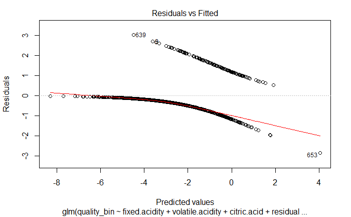

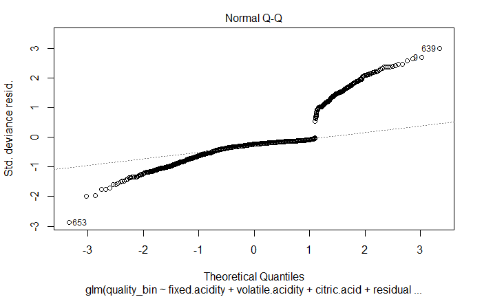

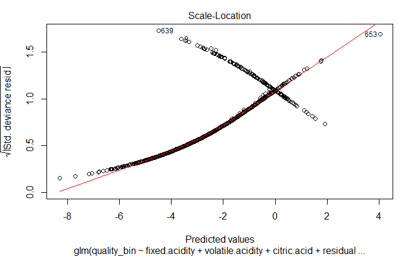

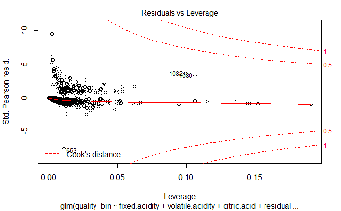

```r
decision_rlog_tintos = glm(quality_bin ~ fixed.acidity + volatile.acidity + citric.acid + residual.sugar +
                chlorides + free.sulfur.dioxide + total.sulfur.dioxide + density + pH +
                sulphates + alcohol, family=binomial(link='logit'), data=tintos_train)
plot(decision_rlog_tintos)
```

```r
summary(decision_rlog_tintos)
```

```
Call:
glm(formula = quality_bin ~ fixed.acidity + volatile.acidity +
    citric.acid + residual.sugar + chlorides + free.sulfur.dioxide +
    total.sulfur.dioxide + density + pH + sulphates + alcohol,
    family = binomial(link = "logit"), data = tintos_train)

Deviance Residuals:
    Min       1Q   Median       3Q      Max
-2.8483  -0.4358  -0.2337  -0.1352   3.0013

Coefficients:
                       Estimate Std. Error z value Pr(>|z|)
(Intercept)           1.976e+02  1.233e+02   1.602  0.10921
fixed.acidity         2.344e-01  1.447e-01   1.620  0.10524
volatile.acidity     -2.320e+00  8.687e-01  -2.670  0.00758 **
citric.acid           2.029e-01  9.393e-01   0.216  0.82896
residual.sugar        2.316e-01  7.963e-02   2.909  0.00363 **
chlorides            -1.309e+01  4.979e+00  -2.628  0.00858 **
free.sulfur.dioxide   1.454e-02  1.391e-02   1.045  0.29587
total.sulfur.dioxide -1.675e-02  5.315e-03  -3.151  0.00163 **
density              -2.101e+02  1.261e+02  -1.667  0.09556 .
pH                   -1.691e-01  1.129e+00  -0.150  0.88101
sulphates             3.431e+00  5.955e-01   5.762 8.33e-09 ***
alcohol               7.437e-01  1.474e-01   5.045 4.54e-07 ***
---
Signif. codes:  0 *** 0.001 ** 0.01 * 0.05 . 0.1   1

(Dispersion parameter for binomial family taken to be 1)

    Null deviance: 953.29  on 1198  degrees of freedom
Residual deviance: 672.51  on 1187  degrees of freedom
AIC: 696.51

Number of Fisher Scoring iterations: 6
```

### Brancos

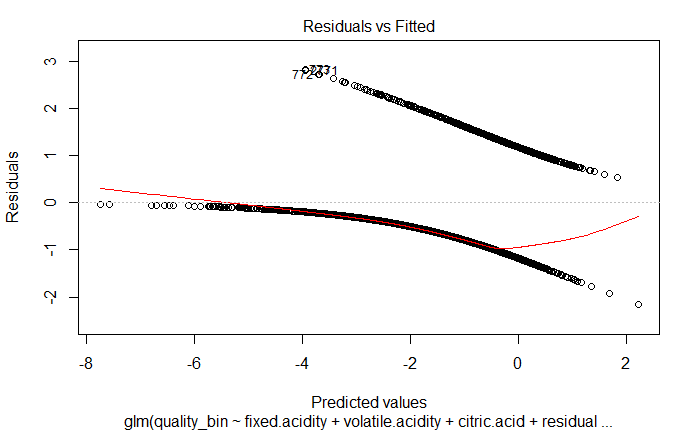

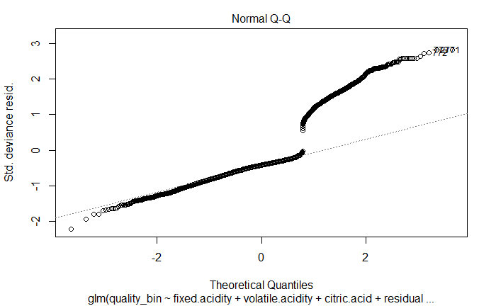

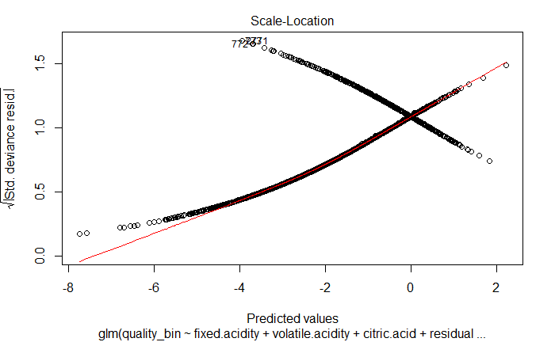

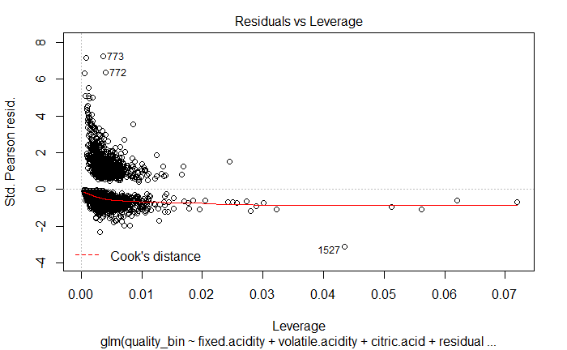

```r
decision_rlog_brancos = glm(quality_bin ~ fixed.acidity + volatile.acidity + citric.acid + residual.sugar +
                chlorides + free.sulfur.dioxide + total.sulfur.dioxide + density + pH +
                sulphates + alcohol, family=binomial(link='logit'), data=brancos_train)
plot(decision_rlog_brancos)
```

```r
summary(decision_rlog_brancos)
```

```
Call:
glm(formula = quality_bin ~ fixed.acidity + volatile.acidity +
    citric.acid + residual.sugar + chlorides + free.sulfur.dioxide +
    total.sulfur.dioxide + density + pH + sulphates + alcohol,
    family = binomial(link = "logit"), data = brancos_train)

Deviance Residuals:
    Min       1Q   Median       3Q      Max
-2.1570  -0.6778  -0.4115  -0.1767   2.8179

Coefficients:
                       Estimate Std. Error z value Pr(>|z|)
(Intercept)           6.239e+02  1.088e+02   5.736 9.71e-09 ***
fixed.acidity         5.474e-01  1.040e-01   5.263 1.42e-07 ***
volatile.acidity     -3.816e+00  5.621e-01  -6.789 1.13e-11 ***
citric.acid          -7.194e-01  4.446e-01  -1.618   0.1057
residual.sugar        2.797e-01  4.094e-02   6.833 8.32e-12 ***
chlorides            -1.347e+01  4.339e+00  -3.105   0.0019 **
free.sulfur.dioxide   8.698e-03  3.700e-03   2.351   0.0187 *
total.sulfur.dioxide -2.053e-04  1.744e-03  -0.118   0.9063
density              -6.461e+02  1.102e+02  -5.861 4.61e-09 ***
pH                    3.272e+00  4.926e-01   6.643 3.07e-11 ***
sulphates             2.122e+00  3.973e-01   5.341 9.26e-08 ***
alcohol               1.232e-01  1.322e-01   0.932   0.3515
---
Signif. codes:  0 *** 0.001 ** 0.01 * 0.05 . 0.1   1

(Dispersion parameter for binomial family taken to be 1)

    Null deviance: 3837.3  on 3672  degrees of freedom
Residual deviance: 3124.6  on 3661  degrees of freedom
AIC: 3148.6

Number of Fisher Scoring iterations: 6
```

### Sobre a tecnica

Essa tecnica cria uma funcao binomial sigmoide para executar uma categorizacao binaria dos dados

### Qualidade do modelo

#### Percentual de acerto da regressao logistica na base de teste dos vinhos tintos

```r
library(ramify)
library(SDMTools)
prediction_rlog_tintos = predict(decision_rlog_tintos, tintos_test)
confusion.matrix(tintos_test$quality_bin, prediction_rlog_tintos, threshold = 0.5)
```

```
    obs
pred   0  1
   0 345 41
   1   1 13
attr(,"class")
[1] "confusion.matrix"
```

#### Percentual de acerto da regressao logistica na base de teste dos vinhos branco

```r
library(ramify)
library(SDMTools)
prediction_rlog_brancos = predict(decision_rlog_brancos, brancos_test)
confusion.matrix(brancos_test$quality_bin, prediction_rlog_brancos, threshold = 0.5)
```

```
    obs
pred   0   1
   0 946 227
   1  14  38
attr(,"class")
[1] "confusion.matrix"
```

## Comparacao entre os modelos:

#### Regressao Logistica: Não e possivel comparar pois foi necessario transformar a variavel dependente